# vehicle sillhoute (5) (2) (2) - Jupyter Notebook

### 1.2:Gini Index

```
xxxxxxxxxx
```

```
In the classification process for our dataset, one of the matrics that we will going to use is the Gini index. it serves as a pivotal metric to gauge the efficacy of silhouette-based features in the categorization of vehicles into three distinct classes: cars, vans, or buses. This widely-adopted metric plays a crucial role in evaluating the impurity of decision tree nodes, offering valuable insights into the model's capacity to make precise predictions grounded in the specified attributes. By leveraging the Gini index, we aim to delve into the intricate patterns and relationships within the dataset, ultimately enhancing our understanding of how well the selected features contribute to the accurate classification of vehicle silhouettes.
```

In the classification process for our dataset, one of the matrics that we will going to use is the Gini index. it serves as a pivotal metric to gauge the efficacy of silhouette-based features in the categorization of vehicles into three distinct classes: cars, vans, or buses. This widely-adopted metric plays a crucial role in evaluating the impurity of decision tree nodes, offering valuable insights into the model's capacity to make precise predictions grounded in the specified attributes. By leveraging the Gini index, we aim to delve into the intricate patterns and relationships within the dataset, ultimately enhancing our understanding of how well the selected features contribute to the accurate classification of vehicle silhouettes.

```
xxxxxxxxxx
```

```
<h4>1.2.a:Training set of 200 </h4>
```

#### 1.2.a:Training set of 200

```
xxxxxxxxxx
```

```
# Set a fixed random seed for reproducibility
```

```
set.seed(234)
```

```
# Randomly sample row indices for the training set
```

```
train_indices <- sample(1:nrow(dataset), 200)
```

```
# Create the training set by selecting rows based on the sampled indices
```

```
Vehicle.train <- dataset[train_indices, ]
```

```
# Create the testing set by excluding rows from the training set
```

```
Vehicle.test <- dataset[-train_indices, ]
```

```
# Extract the target variable for the testing set
```

```
class.test <- dataset$class[-train_indices]
```

```
# Fit a classification tree to your Vehicle Silhouettes dataset
```

```
fit.tree <- rpart(Class ~ ., data = Vehicle.train, method = "class", cp = 0.008)
```

```
# Print the fitted tree
```

```
fit.tree
```

```
xxxxxxxxxx
```

```
<pre>n= 200
```

```
node), split, n, loss, yval, (yprob)
```

```
      * denotes terminal node
```

```
 1) root 200 123 1 (0.38500000 0.33500000 0.28000000)
```

```
   2) scatter_ratio>=139.5 162  85 1 (0.47530864 0.36419753 0.16049383)
```

```
     4) max.length_aspect_ratio< 8.5 97  23 1 (0.76288660 0.22680412 0.01030928)
```

```
       8) circularity>=41.5 68   8 1 (0.88235294 0.11764706 0.00000000) *
```

```
       9) circularity< 41.5 29  15 1 (0.48275862 0.48275862 0.03448276)
```

```
        18) pr.axis_aspect_ratio>=65.5 13   1 1 (0.92307692 0.07692308 0.00000000) *
```

```
        19) pr.axis_aspect_ratio< 65.5 16   3 2 (0.12500000 0.81250000 0.06250000) *
```

```
     5) max.length_aspect_ratio>=8.5 65  28 2 (0.04615385 0.56923077 0.38461538)
```

```
      10) scatter_ratio>=164.5 37   0 2 (0.00000000 1.00000000 0.00000000) *
```

```
      11) scatter_ratio< 164.5 28   3 3 (0.10714286 0.00000000 0.89285714) *
```

```
   3) scatter_ratio< 139.5 38   8 3 (0.00000000 0.21052632 0.78947368)
```

```
     6) max.length_rectangularity< 127.5 10   3 2 (0.00000000 0.70000000 0.30000000) *
```

```
     7) max.length_rectangularity>=127.5 28   1 3 (0.00000000 0.03571429 0.96428571) *</pre>
```

```
n= 200

node), split, n, loss, yval, (yprob)
      * denotes terminal node

 1) root 200 123 1 (0.38500000 0.33500000 0.28000000)
   2) scatter_ratio>=139.5 162  85 1 (0.47530864 0.36419753 0.16049383)
     4) max.length_aspect_ratio< 8.5 97  23 1 (0.76288660 0.22680412 0.01030928)
       8) circularity>=41.5 68   8 1 (0.88235294 0.11764706 0.00000000) *
       9) circularity< 41.5 29  15 1 (0.48275862 0.48275862 0.03448276)
        18) pr.axis_aspect_ratio>=65.5 13   1 1 (0.92307692 0.07692308 0.00000000) *
        19) pr.axis_aspect_ratio< 65.5 16   3 2 (0.12500000 0.81250000 0.06250000) *
     5) max.length_aspect_ratio>=8.5 65  28 2 (0.04615385 0.56923077 0.38461538)
      10) scatter_ratio>=164.5 37   0 2 (0.00000000 1.00000000 0.00000000) *
      11) scatter_ratio< 164.5 28   3 3 (0.10714286 0.00000000 0.89285714) *
   3) scatter_ratio< 139.5 38   8 3 (0.00000000 0.21052632 0.78947368)
     6) max.length_rectangularity< 127.5 10   3 2 (0.00000000 0.70000000 0.30000000) *
     7) max.length_rectangularity>=127.5 28   1 3 (0.00000000 0.03571429 0.96428571) *
```

```
xxxxxxxxxx
```

```
The decision tree results demonstrate a structured approach to classifying vehicle silhouettes based on key features such as scatter ratio, max length aspect ratio, and circularity. The tree efficiently divides the dataset into terminal nodes, outlining distinct decision paths for assigning vehicles to one of three classes: cars, vans, or buses. Notably, the tree prioritizes certain features and their specific thresholds, underscoring their significance in determining the category of a given vehicle silhouette. The analysis of the tree reveals a nuanced hierarchy, reflecting the complexity of the classification process and the interplay of various silhouette-based attributes in making accurate predictions.
```

The decision tree results demonstrate a structured approach to classifying vehicle silhouettes based on key features such as scatter ratio, max length aspect ratio, and circularity. The tree efficiently divides the dataset into terminal nodes, outlining distinct decision paths for assigning vehicles to one of three classes: cars, vans, or buses. Notably, the tree prioritizes certain features and their specific thresholds, underscoring their significance in determining the category of a given vehicle silhouette. The analysis of the tree reveals a nuanced hierarchy, reflecting the complexity of the classification process and the interplay of various silhouette-based attributes in making accurate predictions.

```
xxxxxxxxxx
```

```
#Visualize the Classification Tree
```

```
library(rpart.plot)
```

```
rpart.plot(fit.tree)
```

```
xxxxxxxxxx
```

```
![lena1-2.png](attachment:lena1-2.png)
```

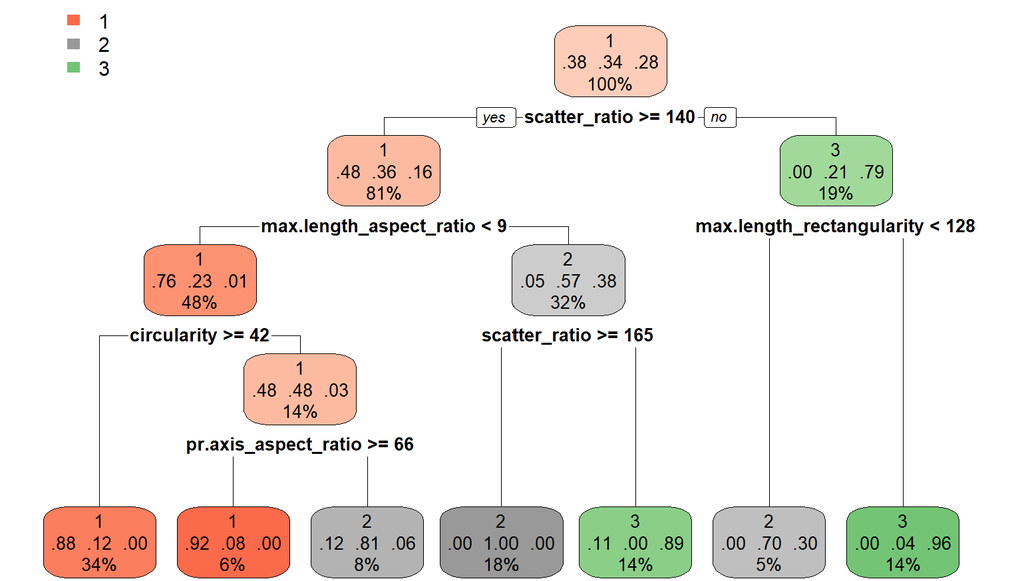

```
xxxxxxxxxx
```

```
The decision tree analysis for the Vehicle Silhouettes dataset reveals insightful patterns in classifying vehicle types.
```